# GeRgraphy

16 March, 2016

## GIS

### Geographic Information Systems

## GIS

### Geographic Information Systems

- incorporating
- storing
- manipulating
- analyzing
- displaying…

## Spatial Data

## What is spatial data?

Nonspatial data **has no** location information

```r
nonspatial = data.frame(
  id=c(1,2,3,4),
  data=rnorm(4)
)
print(nonspatial)
```

```
##   id        data
## 1  1 -0.18440315
## 2  2  0.71289709
## 3  3  0.07569525
## 4  4 -0.29302491
```

## What is spatial data?

Spatial data **has** location information

The simplest spatial data are points on a map

```r
spatial = data.frame(
  id=c(1,2,3,4),
  data=rnorm(4),
  x=runif(4,-180,180),
  y=runif(4,-90,90)
)
print(spatial)
```

```
##   id       data          x         y
## 1  1  1.1078521 -163.31586 -17.09215
## 2  2  0.6823303   24.80689 -16.19491
## 3  3 -0.8240628  -48.30838  68.72671
## 4  4 -1.0572702 -138.16606  76.15166
```

## What is spatial data?

Which we can convert to explicitly spatial data using the `sp` package. Most GIS packages in R store data as `sp` classes.

```r
library(sp)
```

## What is spatial data?

The `sp` package has a method called `coordinates` that converts points to an `sp` class.

```r
coordinates(spatial) = ~ x + y
class(spatial)
```

```
## [1] "SpatialPointsDataFrame"
## attr(,"package")
## [1] "sp"
```

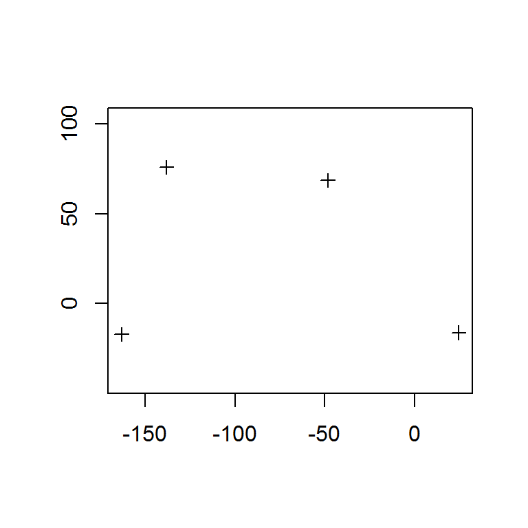

```r
plot(spatial, axes=T)
```

## What is spatial data?

Spatial data also needs a reference system or **"projection"** that allows us to represent spatial features on a map. Projections can be thought of as simply a coordinate system with an origin that is relative to a known point in space.

This is a whole field of mathematically intensive study termed "geodesy"

Much of the field of geodesy is jam-packed in the `rgdal` package, which is a wrapper for the **G**eospatial **D**ata **A**bstration **L**ibrary

```r
library(rgdal)
```

## What is spatial data?

`rgdal` includes a comprehensive list of projections that are typically represented as a **string of parameters**.

The most common is our standard latitude/longitude system, where the coordinates are angular and the origin is the equator directly south of Greenwich, England. The simplest projection string to denote this projections is:

`"+proj=longlat"`

To define the projection for `spatial`, we write to its `proj4string` slot:

```r
proj4string(spatial) = "+proj=longlat"
```

Projections are a necessary evil for GIS users (to be continued)

## What is spatial data?

With a projection associated with our spatial data, we can now relate it to other spatial data. In other words, let's make a map!

```r
library(leaflet)
```

```r
m = leaflet(data=spatial) %>%
  addTiles() %>%
  addMarkers()
m
```

## What is spatial data?

[interactive chart not shown]

## Spatial data types

## Spatial data types

### Two main types: vector and raster

Vector = Polygons  
Raster = Grid  
Vector = Discrete  
Raster = Continuous  
Vector = Illustrator/Inkscape  
Raster = Photoshop/GIMP

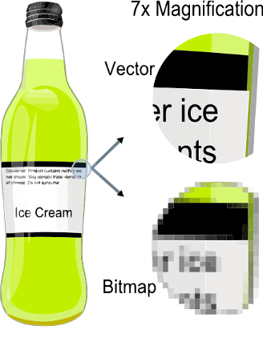

## Vector Data

## Intro

## Vector I/O

```r
library(rgdal)
```

## Vector I/O

```r
soils = readOGR(dsn="data", layer="soilsData")
writeOGR(
  soils,
  "data",
  "soilsData_out",
  driver="ESRI Shapefile"
)
```

## Vector data structure

```r
class(soils)
```

```
## [1] "SpatialPolygonsDataFrame"
## attr(,"package")
## [1] "sp"
```

```r
slotNames(soils)
```

```
## [1] "data"        "polygons"    "plotOrder"   "bbox"        "proj4string"
```

## Vector data structure

Take a peak here at the top of our attribute table

```r
str(soils@data[,1:5])
```

```
## 'data.frame':    75 obs. of  5 variables:
##  $ mukey  : Factor w/ 25 levels "2774742","2774772",..: 12 19 12 6 9 5 7 24 25 13 ...
##  $ muarcrs: Factor w/ 75 levels "0.40538405","0.90105194",..: 25 62 70 19 3 29 20 7 5 27 ...
##  $ Sand1  : num  21.5 11 21.5 12 29.5 ...
##  $ Sand2  : num  35.29 8.34 35.29 9.02 38.22 ...
##  $ Sand3  : num  45.09 7.56 45.09 16.59 64.52 ...
```

*Make sure not to call `head()` or `str()` on a spatial object, as this spits out the first six features and all their attributes

## Vector data structure

```r
str(soils@data[,1:10])
```

```
## 'data.frame':    75 obs. of  10 variables:
##  $ mukey  : Factor w/ 25 levels "2774742","2774772",..: 12 19 12 6 9 5 7 24 25 13 ...
##  $ muarcrs: Factor w/ 75 levels "0.40538405","0.90105194",..: 25 62 70 19 3 29 20 7 5 27 ...
##  $ Sand1  : num  21.5 11 21.5 12 29.5 ...
##  $ Sand2  : num  35.29 8.34 35.29 9.02 38.22 ...
##  $ Sand3  : num  45.09 7.56 45.09 16.59 64.52 ...
##  $ Sand4  : num  48.6 30.6 48.6 36.7 33.2 ...
##  $ Sand5  : num  0 31.1 0 27.1 57.2 ...
##  $ Silt1  : num  45.8 65.2 45.8 68.7 54.5 ...
##  $ Silt2  : num  37.3 64.9 37.3 60.3 43.5 ...
##  $ Silt3  : num  36.7 64.1 36.7 34 21.1 ...
```

## Vector data structure

```r
str(soils@polygons[1])
```

```
## List of 1
##  $ :Formal class 'Polygons' [package "sp"] with 5 slots
##   .. ..@ Polygons :List of 1
##   .. .. ..$ :Formal class 'Polygon' [package "sp"] with 5 slots
##   .. .. .. .. ..@ labpt  : num [1:2] -90.1 43.1
##   .. .. .. .. ..@ area   : num 1.19e-06
##   .. .. .. .. ..@ hole   : logi FALSE
##   .. .. .. .. ..@ ringDir: int 1
##   .. .. .. .. ..@ coords : num [1:21, 1:2] -90.1 -90.1 -90.1 -90.1 -90.1 ...
##   .. ..@ plotOrder: int 1
##   .. ..@ labpt    : num [1:2] -90.1 43.1
##   .. ..@ ID       : chr "0"
##   .. ..@ area     : num 1.19e-06
```

## Vector data structure

Number of features

```r
length(soils)
```

```
## [1] 75
```

## Vector data structure

Index the first feature with a slice

```r
poly_1 = soils[1,]
```

## Plotting

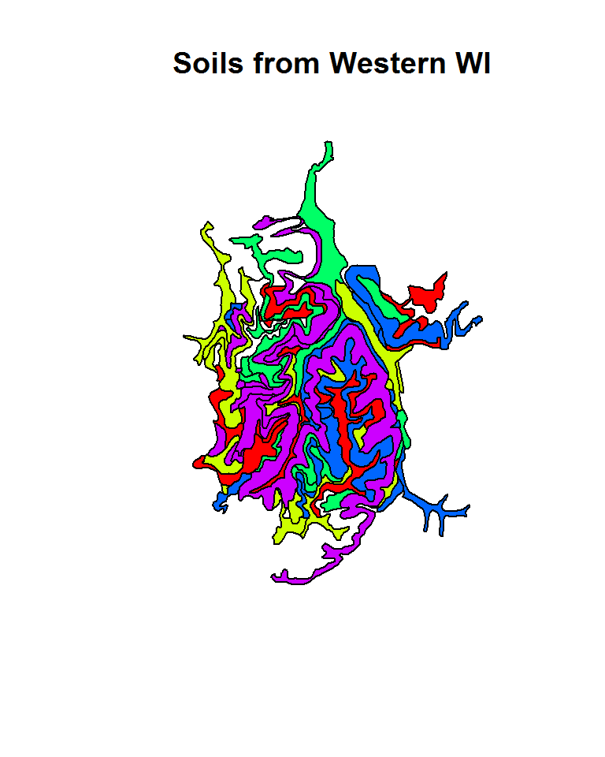

```r
plot(
  soils,
  main="Soils from Western WI",
  col=rainbow(5)
)
```

## Working with Vector Data

## Raster Data

## Intro

A raster **grid** is rectangular.

**Grid** is another word for **matrix**.

**Grid** is another word for **image**.

A GIS raster **grid** is a **matrix/image** with an associated location and projection.

## Intro

At a minimum, a GIS raster grid contains:

1. matrix of values
2. projection
3. reference point, often (x,y) of the lower-left corner
4. cellsize

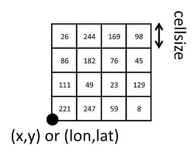

## Raster I/O

The rgdal `rgdal` packages is primarily for I/O and projecting GIS data

```r
library(rgdal)
```

The `raster` package does everything `rgdal` does, but it includes lots of additional functionality.

```r
library(raster)
```

## Raster I/O

```r
elev = readGDAL("data/dem_wi.tif")
writeGDAL(elev, "data/dem_wi_out.tif")
```

```r
elev = raster("data/dem_wi.tif")
writeRaster(elev, "data/dem_wi_out.tif")
```

## Raster data structure

The raster object `elev` has all the necessary pieces of spatial information:

```r
elev
```

```
## class       : RasterLayer
## dimensions  : 284, 387, 109908  (nrow, ncol, ncell)
## resolution  : 0.01666667, 0.01666667  (x, y)
## extent      : -93.03262, -86.58262, 42.3949, 47.12823  (xmin, xmax, ymin, ymax)
## coord. ref. : +proj=longlat +datum=WGS84 +no_defs +ellps=WGS84 +towgs84=0,0,0
## data source : C:\Users\ruesca\Documents\GeRgraphyPresentation\data\dem_wi.tif
## names       : dem_wi
## values      : 175, 570  (min, max)
## attributes  :
##         ID Rowid COUNT
##  from: 167     0     1
##  to  : 593   425     2
```

## Raster data structure

Which means we can make a map!

```r
m = leaflet() %>%
  addTiles() %>%
  addRasterImage(elev, opacity=0.5)
m
```

## Raster data structure

[interactive chart not shown]

## Raster analysis

Remember that rasters are just matrices!

Therefore, most matrix algebra can be applied to rasters

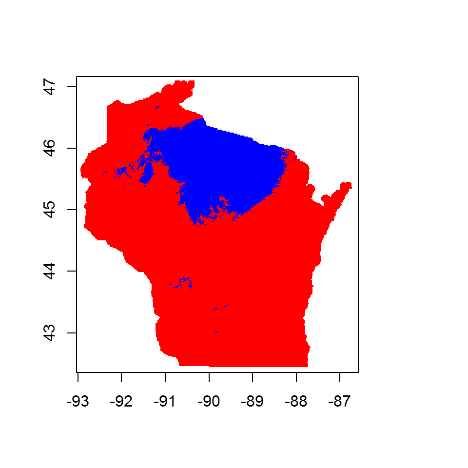

```r
plot(
  elev > 400,
  col=c("red", "blue")
)
```

## Raster analysis

Rasters can be easily converted to matrices to do more complex work.

[figure not shown]

```r
lat_grad = apply(
  as.matrix(elev),
  1,
  mean,
  na.rm=T
)
plot(lat_grad, type="l")
```

## Raster overlay

Most raster analysis ultimately executes some sort of **overlay.**

The issue:

> To overlay two or more rasters, their projections, extents, and cellsizes must align perfectly.

This is not necessarily an easy task.

## Raster overlay

### coordinate systems

What is the highest point in each county?

## Raster overlay

### coordinate systems

```r
counties = readOGR("data", "WI_Counties")
```

```r
proj4string(counties)
```

```
## [1] "+proj=tmerc +lat_0=0 +lon_0=-90 +k=0.9996 +x_0=520000 +y_0=-4480000 +ellps=GRS80 +units=m +no_defs"
```

```r
proj4string(elev)
```

```
## [1] "+proj=longlat +datum=WGS84 +no_defs +ellps=WGS84 +towgs84=0,0,0"
```

## Raster overlay

### coordinate systems

```r
extent(counties)
```

```
## class       : Extent
## xmin        : 294839
## xmax        : 770036.4
## ymin        : 225108.8
## ymax        : 734398.4
```

```r
extent(elev)
```

```
## class       : Extent
## xmin        : -93.03262
## xmax        : -86.58262
## ymin        : 42.3949
## ymax        : 47.12823
```

## Raster overlay

### coordinate systems

cty = rasterize(counties, elev, field="COUNTY_FIP")

## A Necessary Evil

Here we'll discuss the situation where you will read in a table of points, that does not have any spatial reference system attached to it.